# BT1101-Tutorial 3 (Due 13/9 8am)

Lo Zhi Hao

9/9/2021

### Tutorial 3 Question 2 (To be Submitted; 20 marks)

- Dataset required: `marketing_campaign.xlsx`

This data set contains data on 2240 customers involved in a marketing campaign of a company with both physical and online presence. Each of the column is defined as follows:

- `ID` : customer unique identifier
- `Year_Birth` : customer year of birth
- `Education` : customer’s level of education
- `Marital_Status`: customer’s marital status
- `Income` : customer’s yearly household income
- `Kidhome` : number of small children in customer’s household
- `Teenhome` : number of teenagers in customer’s household
- `Dt_Customer`: date of customer’s enrollment with the company
- `Recency` : number of days since the last purchase
- `MntWines` : amount spent on wine products in the last 2 years
- `MntFruits` : amount spent on fruits products in the last 2 years
- `MntMeatProducts` : amount spent on meat products in the last 2 years
- `MntFishProducts` : amount spent on fish products in the last 2 years
- `MntSweetProducts` : amount spent on sweet products in the last 2 years
- `MntGoldProds` : amount spent on gold products in the last 2 years
- `NumDealsPurchases` : number of purchases made with discount
- `NumWebPurchases` : number of purchases made through company’s web site
- `NumCatalogPurchases` : number of purchases made using catalogue
- `NumStorePurchases` : number of purchases made directly in stores
- `NumWebVisitsMonth` : number of visits to company’s web site in the last month
- `AcceptedCmp3` : 1 if customer accepted the offer in the 3rd campaign, 0 otherwise
- `AcceptedCmp4` : 1 if customer accepted the offer in the 4th campaign, 0 otherwise
- `AcceptedCmp5` : 1 if customer accepted the offer in the 5th campaign, 0 otherwise
- `AcceptedCmp1` : 1 if customer accepted the offer in the 1st campaign, 0 otherwise
- `AcceptedCmp2` : 1 if customer accepted the offer in the 2nd campaign, 0 otherwise
- `Response`` : 1 if customer accepted the offer in the last campaign, 0 otherwise
- `Complain` : 1 if customer complained in the last 2 years

```r
#put in your working directory folder pathname
library(readxl)

#import excel file into RStudio
Df <- read_excel("marketing_campaign.xlsx", sheet="Sheet4")
#summary(Df)
```

**Now you will build some dashboards to help the marketing manager understand the customers and the marketing campaign better.**

### Q2.(a) Customer Dashboard

The marketing manager has the following requirements for the Customer dashboard:

- 1. To be able to visualize the frequency distributions for customer age, education levels, marital status, number of small children in their household, number of teenagers in their household and yearly household income. Use the most appropriate charts for each variable. (6 marks)
- 2. To be able to view, in a table, the frequency distribution of customers who complain versus do not complain, by education and marital status. (1 mark)
- 3. In your answer below, describe any interesting insights or patterns you can derive from the charts. (2 marks)

**BEGIN: YOUR ANSWER**

```r
library(dplyr)
library(knitr)
library(tidyr)
library(rpivotTable)
```

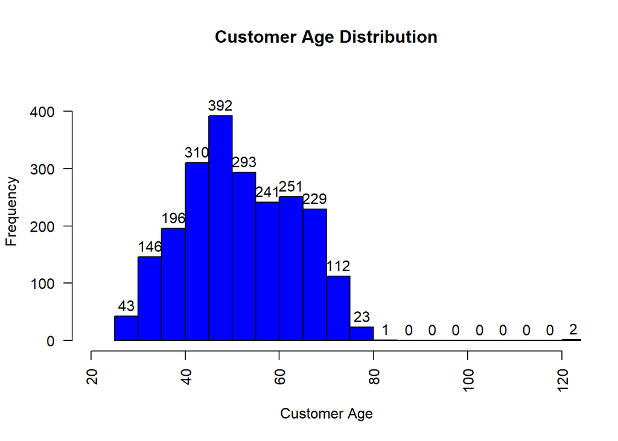

```r
#2ai
#Plotting Customer Age using Histogram (Continuous Variable)
CusAge <- Df %>% select(ID, Year_Birth) %>% mutate(Age=2021-Year_Birth)
#CusAge
h1 <- hist(CusAge$Age, main="Customer Age Distribution", freq=TRUE, xlim=c(20, 120), xlab="Customer Age", ylab="Frequency", labels=TRUE, breaks=20, axes=TRUE, ylim=c(0,450), col="blue", las=2)
```

```r
#h1
AgeGrp <- cut(CusAge$Age, h1$breaks)
t1 <- table(AgeGrp)
kable(t1, caption="Age of Customers")
```

Age of Customers

| AgeGrp | Freq |
| --- | --- |
| (25,30] | 41 |
| (30,35] | 146 |
| (35,40] | 196 |
| (40,45] | 310 |
| (45,50] | 392 |
| (50,55] | 293 |
| (55,60] | 241 |
| (60,65] | 251 |
| (65,70] | 229 |
| (70,75] | 112 |
| (75,80] | 23 |
| (80,85] | 1 |
| (85,90] | 0 |
| (90,95] | 0 |
| (95,100] | 0 |
| (100,105] | 0 |
| (105,110] | 0 |
| (110,115] | 0 |
| (115,120] | 0 |
| (120,125] | 2 |
| (125,130] | 1 |

```r
#Plotting Customer Education level using pie chart (Discrete Variable)
CusEdu <- Df %>% group_by(Education) %>% count(Education)
#CusEdu
kable(CusEdu, caption="Customer Education Level")
```

Customer Education Level

| Education | n |
| --- | --- |
| 2n Cycle | 203 |
| Basic | 54 |
| Graduation | 1127 |
| Master | 370 |
| PhD | 486 |

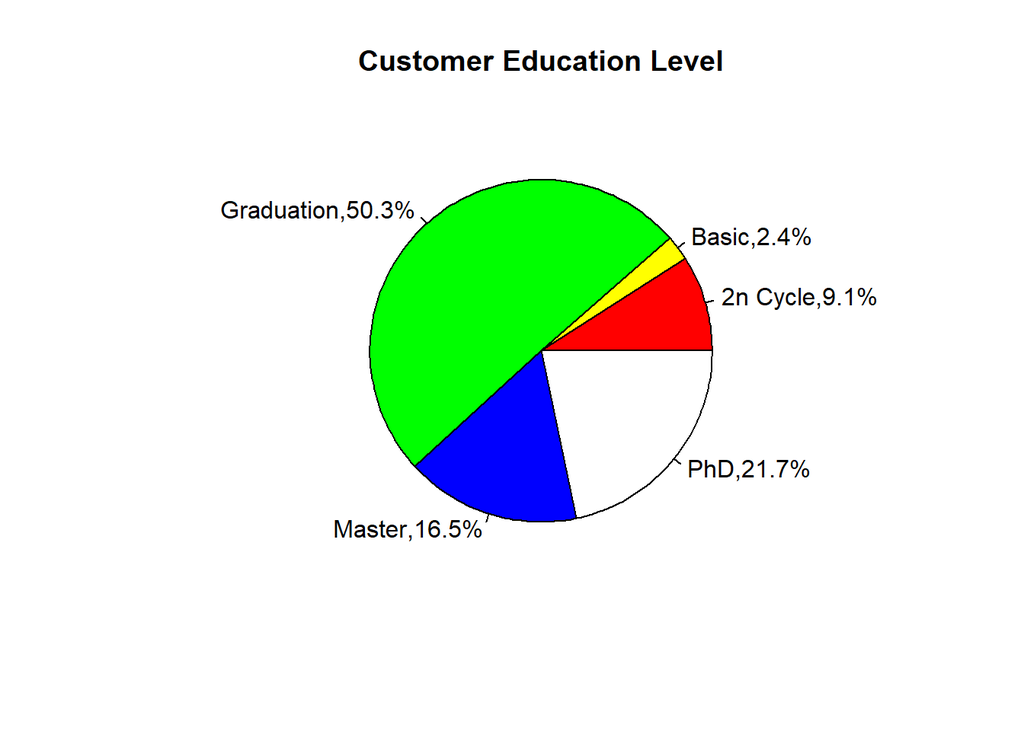

```r
label <- CusEdu$Education
label <- paste(label, ",", sep="")
label <- paste(label, round(CusEdu$n/sum(CusEdu$n) * 100, 1), sep="")
label <- paste(label, "%", sep="")
pie(CusEdu$n, labels=label, col=c("red", "yellow", "green", "blue", "white"), main="Customer Education Level")
```

```r
#Plotting Customer Marital Status using Barplot (Discrete Variable)
CusMar <- Df %>% group_by(Marital_Status) %>% count()
#CusMar$Marital_Status
CusMar.matrix <- as.matrix(CusMar$n)
#CusMar.matrix
colours <- c("red", "orange", "yellow", "green", "blue", "aquamarine", "white")
kable(CusMar, caption="Customer Marital Status")
```

Customer Marital Status

| Marital_Status | n |
| --- | --- |
| Absurd | 2 |
| Alone | 3 |
| Divorced | 232 |
| Married | 864 |
| Single | 480 |
| Together | 580 |
| Widow | 77 |
| YOLO | 2 |

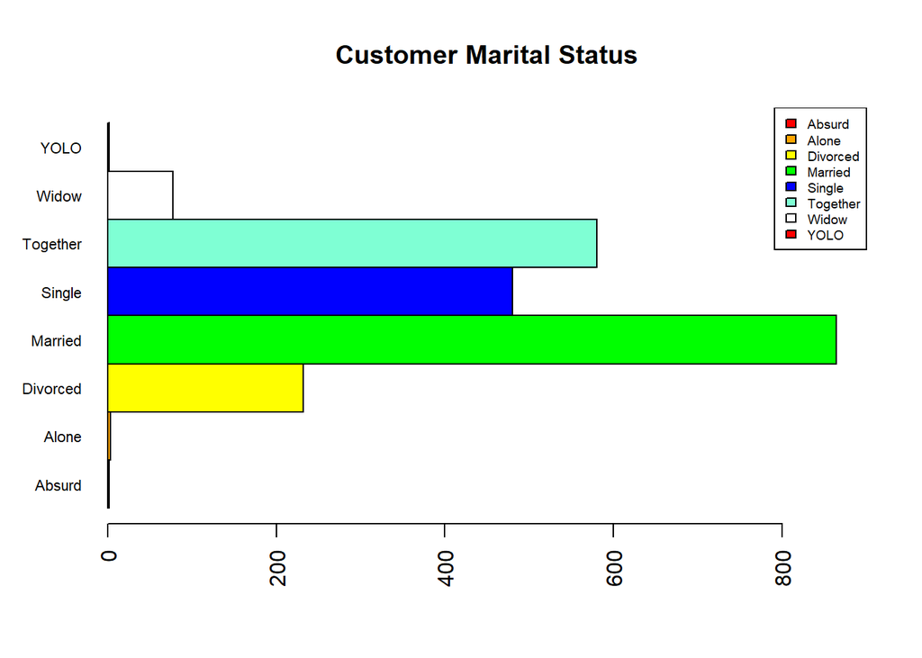

```r
barplot(CusMar.matrix, col=colours, xlim=c(0, 900), main="Customer Marital Status", beside=TRUE, names=CusMar$Marital_Status, cex.names = 0.7, las=2, horiz=TRUE)
legend("topright", legend=CusMar$Marital_Status, fill=colours, cex=0.6)
```

```r
#Plotting the number of Children of Customers at Home using Barplot (Discrete Variable)
CusKid <- Df %>% count(Kidhome)
#CusKid
label <- CusKid$Kidhome
label <- paste(label, " Children,", sep="")
label <- paste(label, CusKid$n, sep="")
label <- paste(label, ",", sep="")
label <- paste(label, round(CusKid$n/sum(CusKid$n) * 100, 1), sep="")
label <- paste(label, "%", sep="")
kable(CusKid, caption="Number of Small Children in Customer Household")
```

Number of Small Children in Customer Household

| Kidhome | n |
| --- | --- |
| 0 | 1293 |
| 1 | 899 |
| 2 | 48 |

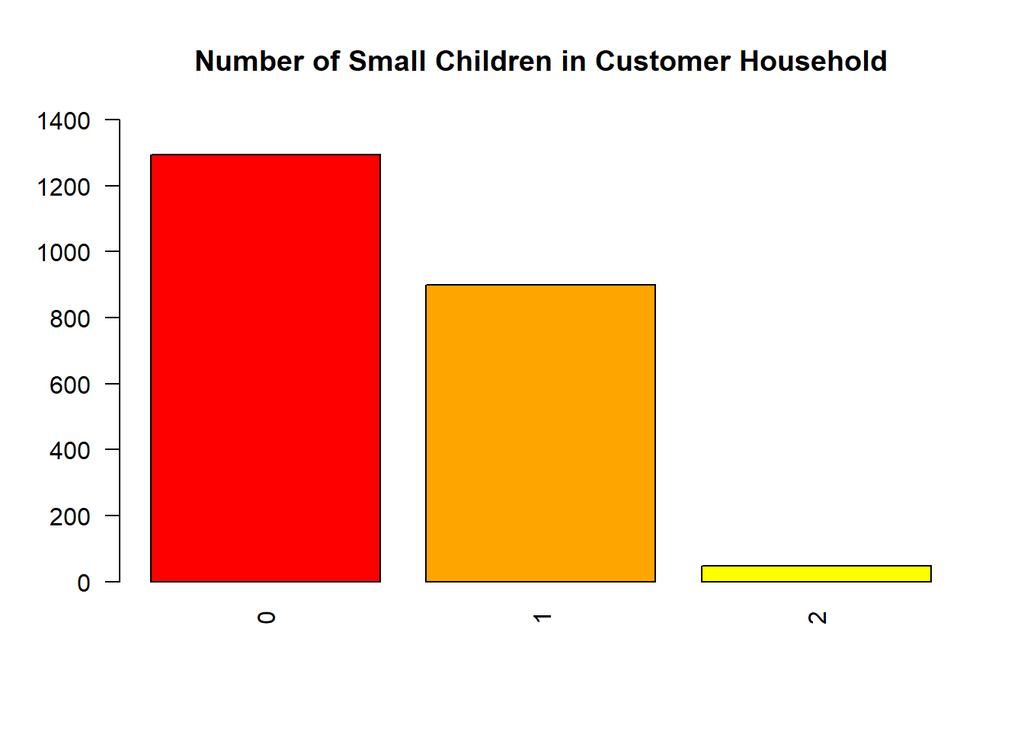

```r
barplot(CusKid$n, col=colours, main="Number of Small Children in Customer Household", ylim=c(0, 1400), names=CusKid$Kidhome, las=2)
```

```r
#Plotting the number of Teenagers of Customers at Home using Barplot (Discrete Variable)
CusTeen <- Df %>% count(Teenhome)
#CusTeen
label <- CusTeen$Teenhome
label <- paste(label, " Teenager(s),", sep="")
label <- paste(label, CusTeen$n, sep="")
label <- paste(label, ",", sep="")
label <- paste(label, round(CusTeen$n/sum(CusTeen$n) * 100, 1), sep="")
label <- paste(label, "%", sep="")
kable(CusTeen, caption="Number of Teenagers in Customer Household")
```

Number of Teenagers in Customer Household

| Teenhome | n |
| --- | --- |
| 0 | 1158 |
| 1 | 1030 |
| 2 | 52 |

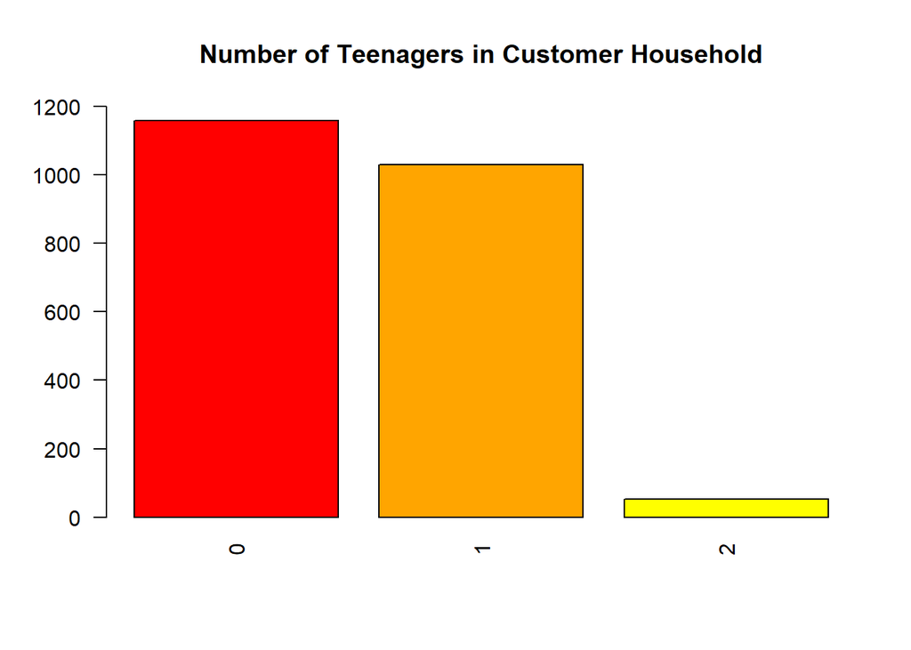

```r
barplot(CusTeen$n, col=colours, main="Number of Teenagers in Customer Household", names=CusTeen$Teenhome, ylim=c(0, 1200), las=2)
```

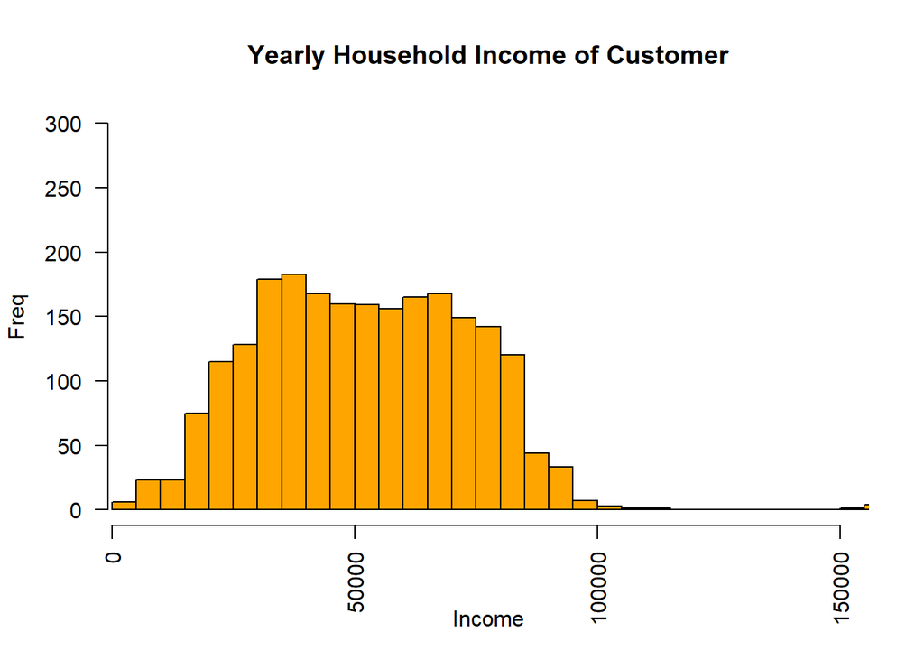

```r
#Plotting the yearly Household Income of Customer using Histogram (Continuous Variable)
#CusInc <- Df %>% filter(Df$Income<150000)
h2 <- hist(Df$Income, freq=TRUE, main="Yearly Household Income of Customer", xlim=c(5000, 150000), breaks=200, labels=FALSE, xlab="Income", ylab="Freq", axes=TRUE, ylim=c(0, 300), col="orange", las=2)
```

```r
Df.incgrp <- cut(Df$Income, h2$breaks)
t2 <- table(Df.incgrp)
kable(t2, caption="Yearly Income of Customers")
```

Yearly Income of Customers

| Df.incgrp | Freq |
| --- | --- |
| (0,5e+03] | 6 |
| (5e+03,1e+04] | 23 |
| (1e+04,1.5e+04] | 23 |
| (1.5e+04,2e+04] | 75 |
| (2e+04,2.5e+04] | 115 |
| (2.5e+04,3e+04] | 128 |
| (3e+04,3.5e+04] | 179 |
| (3.5e+04,4e+04] | 183 |
| (4e+04,4.5e+04] | 168 |
| (4.5e+04,5e+04] | 160 |
| (5e+04,5.5e+04] | 159 |
| (5.5e+04,6e+04] | 156 |
| (6e+04,6.5e+04] | 165 |
| (6.5e+04,7e+04] | 168 |
| (7e+04,7.5e+04] | 149 |
| (7.5e+04,8e+04] | 142 |
| (8e+04,8.5e+04] | 120 |
| (8.5e+04,9e+04] | 44 |
| (9e+04,9.5e+04] | 33 |
| (9.5e+04,1e+05] | 7 |
| (1e+05,1.05e+05] | 3 |
| (1.05e+05,1.1e+05] | 1 |
| (1.1e+05,1.15e+05] | 1 |
| (1.15e+05,1.2e+05] | 0 |
| (1.2e+05,1.25e+05] | 0 |
| (1.25e+05,1.3e+05] | 0 |
| (1.3e+05,1.35e+05] | 0 |
| (1.35e+05,1.4e+05] | 0 |
| (1.4e+05,1.45e+05] | 0 |
| (1.45e+05,1.5e+05] | 0 |

[output cut: 104 more lines]

```r
#aii
#Creating table for the frequency distribution of customers who complains and who does not complain based on Marital Status and Education Level
CusCom1 <- Df %>% group_by(Education) %>% count(Complain) %>% spread(key=Education, value=n)
CusCom1[is.na(CusCom1)] <- 0
kable(CusCom1, caption="Complain Distribution Between Different Education Levels")
```

Complain Distribution Between Different Education Levels

| Complain | 2n Cycle | Basic | Graduation | Master | PhD |
| --- | --- | --- | --- | --- | --- |
| 0 | 199 | 54 | 1113 | 368 | 485 |
| 1 | 4 | 0 | 14 | 2 | 1 |

```r
CusCom2 <- Df %>% group_by(Marital_Status) %>% count(Complain) %>% spread(key=Marital_Status, value=n)
CusCom2[is.na(CusCom2)] <- 0
kable(CusCom2, caption="Complain Distribution Between Different Marital Status")
```

Complain Distribution Between Different Marital Status

| Complain | Absurd | Alone | Divorced | Married | Single | Together | Widow | YOLO |
| --- | --- | --- | --- | --- | --- | --- | --- | --- |
| 0 | 2 | 3 | 230 | 856 | 474 | 575 | 77 | 2 |
| 1 | 0 | 0 | 2 | 8 | 6 | 5 | 0 | 0 |

```r
#rpivotTable(Df, rows="Complain", cols=c("Education", "Marital_Status"), aggregatorName="count")

#CusChi <- Df %>% mutate(Child=Kidhome + Teenhome) %>% count(Child)
#CusChi
```

Most of the customers of the business is around 40 to 60 years old, while there are some customers that are above 120 years old. Almost 90% of the customers have an education level that is at least above graduation level. All the YOLO Marital Status customers are from PHD education level. Most of the customers have less than 2 children. Most of the customers have a household income that is between 20000 and 80000. Most of the customers who complain are graduate customers.

**END: YOUR ANSWER**

### Q2.(b) Marketing Campaign Dashboard

There were 6 marketing campaigns conducted. Each one with varying degrees of success (in terms of number of customers taking up the offer). The marketing manager hopes this Marketing Campaign Dashboard can help him visualize the results better. In particular, he ask for the following to be on this dashboard:

- 1. A table displaying the number of customers who accepted and did not accept the offer for each of the 6 marketing campaigns (ie: 1st, 2nd, … 6th) (2 marks)
- 2. A chart to visualize the information presented in the table generated above. (2 marks)
- 3. A description of which is the most and least successful campaign. (1 mark)

**BEGIN: YOUR ANSWER**

```r
## Type your codes here
library(dplyr)
library(tidyr)
library(knitr)
library(rpivotTable)

#bi
#Table to display the number of customers who accepted and did not accept the offer for each of the marketing campaign
MarCam1 <- Df %>% count(AcceptedCmp1)
#kable(MarCam1, caption="Marketing Campaign 1 Acceptance")
MarCam2 <- Df %>% count(AcceptedCmp2)
#kable(MarCam2, caption="Marketing Campaign 2 Acceptance")
MarCam3 <- Df %>% count(AcceptedCmp3)
#kable(MarCam3, caption="Marketing Campaign 3 Acceptance")
MarCam4 <- Df %>% count(AcceptedCmp4)
#kable(MarCam4, caption="Marketing Campaign 4 Acceptance")
MarCam5 <- Df %>% count(AcceptedCmp5)
#kable(MarCam5, caption="Marketing Campaign 5 Acceptance")
MarCam6 <- Df %>% count(Response)
#kable(MarCam6, caption="Marketing Campaign 6 Acceptance")
MarCam <- cbind(MarCam1$n, MarCam2$n, MarCam3$n, MarCam4$n, MarCam5$n, MarCam6$n)
colnames(MarCam) <- c("Campaign1", "Campaign2", "Campaign3", "Campaign4", "Campaign5", "Campaign6")
rownames(MarCam) <- c("Declined", "Accepted")
kable(MarCam, caption="Marketing Campaign Acceptance Overview")
```

Marketing Campaign Acceptance Overview

|  | Campaign1 | Campaign2 | Campaign3 | Campaign4 | Campaign5 | Campaign6 |
| --- | --- | --- | --- | --- | --- | --- |
| Declined | 2096 | 2210 | 2077 | 2073 | 2077 | 1906 |
| Accepted | 144 | 30 | 163 | 167 | 163 | 334 |

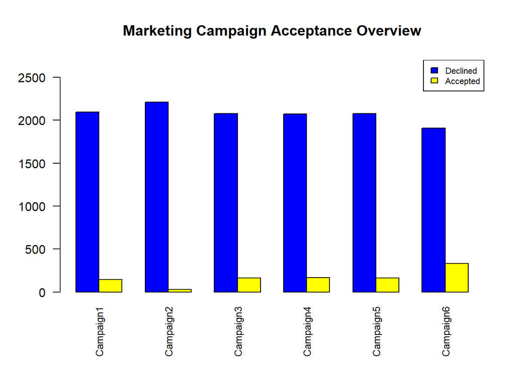

```r
#bii
#Barplot to visualise the discrete data provided in the table generated above
colour <- c( "blue", "yellow")
barplot(MarCam, main="Marketing Campaign Acceptance Overview", beside=TRUE, col=colour, ylim=c(0, 2700), names=c("Campaign1", "Campaign2", "Campaign3", "Campaign4", "Campaign5", "Campaign6"), cex.names=0.8, las=2)
legend("topright", legend=c("Declined", "Accepted"), cex=0.7, fill=colour)
```

Among the six marketing campaigns, **Campaign 6** is the marketing campaign which achieves the highest number of acceptance, with *334* acceptance. On the other hand, **Campaign 2** is the campaign with the lowest number of acceptance, with only *30* acceptance.

**END: YOUR ANSWER**

### Q2.(c) Sales Dashboard

The amount customers spent on various products are captured in the data set. The marketing manager would like this dashboard to help him visualize this data better. In particular, he would like the dashboard to have the following:

- 1. A chart and a corresponding table displaying the frequency distribution for customers’ total amount spent. Total amount spent includes amount spent on wines, fruits, meat products, fish products, sweet products and gold products. The chart and table should be appropriately titled and labeled. (3 marks)
- 2. A chart to see the relationship between total amount spent and annual household income. (1 mark)
- 3. The number and percentage of customers who spent the most, making up 80% of the total amount spent by all customers in the data set. (2 mark)

**BEGIN: YOUR ANSWER**

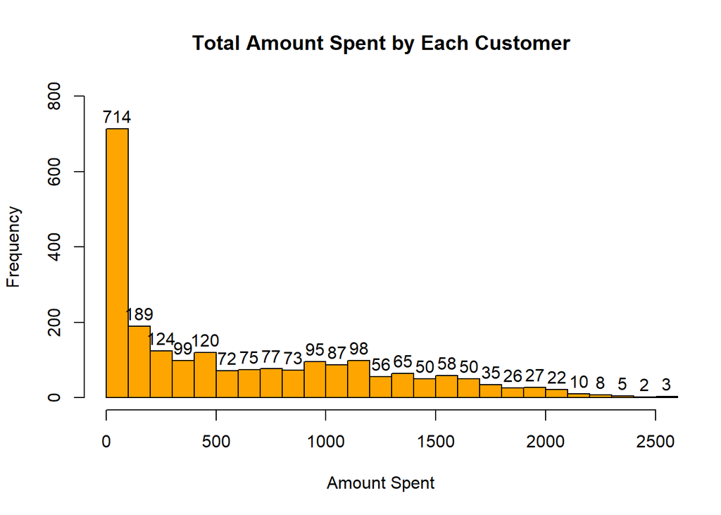

```r
## Type your codes here
library(dplyr)
library(tidyr)
library(knitr)

#ci
CusTot <- Df %>% mutate(Total=MntWines + MntFruits + MntMeatProducts + MntFishProducts + MntSweetProducts + MntGoldProds)
h3 <- hist(CusTot$Total, main="Total Amount Spent by Each Customer", col="orange", xlim=c(0, 2500), ylim=c(0, 800), xlab="Amount Spent", breaks=25, labels=TRUE, axes=TRUE)
```

```r
AmtGrp <- cut(CusTot$Total, h3$breaks)
tbl <- table(AmtGrp)
kable(tbl, caption="Total Amount Spent by Each Customer")
```

Total Amount Spent by Each Customer

| AmtGrp | Freq |
| --- | --- |
| (0,100] | 714 |
| (100,200] | 189 |
| (200,300] | 124 |
| (300,400] | 99 |
| (400,500] | 120 |
| (500,600] | 72 |
| (600,700] | 75 |
| (700,800] | 77 |
| (800,900] | 73 |
| (900,1e+03] | 95 |
| (1e+03,1.1e+03] | 87 |
| (1.1e+03,1.2e+03] | 98 |
| (1.2e+03,1.3e+03] | 56 |
| (1.3e+03,1.4e+03] | 65 |
| (1.4e+03,1.5e+03] | 50 |
| (1.5e+03,1.6e+03] | 58 |
| (1.6e+03,1.7e+03] | 50 |
| (1.7e+03,1.8e+03] | 35 |
| (1.8e+03,1.9e+03] | 26 |
| (1.9e+03,2e+03] | 27 |
| (2e+03,2.1e+03] | 22 |
| (2.1e+03,2.2e+03] | 10 |
| (2.2e+03,2.3e+03] | 8 |
| (2.3e+03,2.4e+03] | 5 |
| (2.4e+03,2.5e+03] | 2 |
| (2.5e+03,2.6e+03] | 3 |

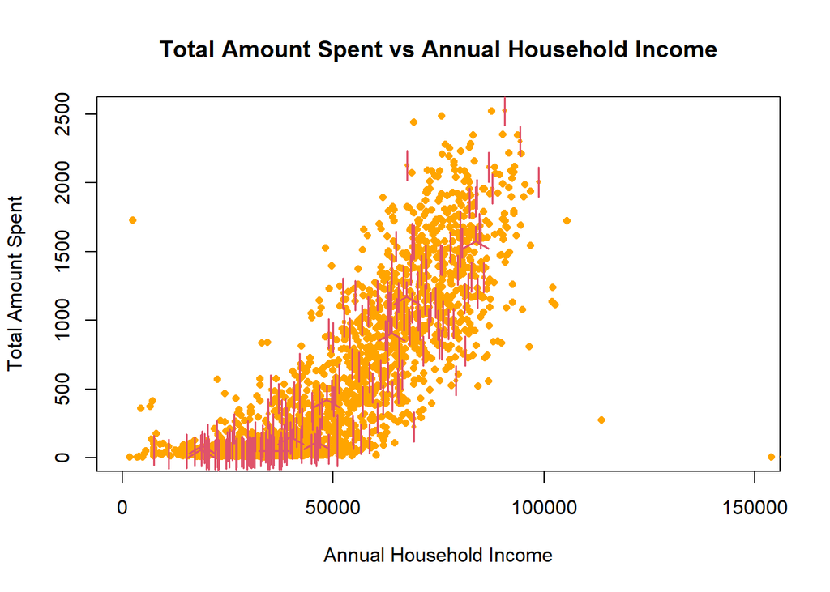

```r
#cii
sunflowerplot(Df$Income, CusTot$Total, xlab="Annual Household Income", ylab="Total Amount Spent", col="orange", xlim=c(0, 150000), main="Total Amount Spent vs Annual Household Income")
```

```r
#ciii
CusTot <- CusTot %>% select(Total) %>% arrange(desc(Total))
CusTot$Percent <- CusTot$Total / sum(CusTot$Total)
CusTot$Cul <- cumsum(CusTot$Percent)
#CusTot$Cultop <- as.numeric(rownames(CusTot)/nrow(CusTot))

num <- which(CusTot$Cul > 0.8)[1]
print(num)
```

```
## [1] 844
```

```r
per <- paste(round(num / nrow(CusTot), 3) * 100, "%")
print(per)
```

```
## [1] "37.7 %"
```

**END: YOUR ANSWER**